# trajectory + data cube exercise

Edzer Pebesma

1/12/2022

In this exercise, we create a data cube from a set of trajectories

## Data

Consider the storms package in `dplyr`:

```r
library(dplyr)
data(storms)
storms
```

```
## # A tibble: 10,010 × 13
##    name   year month   day  hour   lat  long status      category  wind pressure
##    <chr> <dbl> <dbl> <int> <dbl> <dbl> <dbl> <chr>       <ord>    <int>    <int>
##  1 Amy    1975     6    27     0  27.5 -79   tropical d… -1          25     1013
##  2 Amy    1975     6    27     6  28.5 -79   tropical d… -1          25     1013
##  3 Amy    1975     6    27    12  29.5 -79   tropical d… -1          25     1013
##  4 Amy    1975     6    27    18  30.5 -79   tropical d… -1          25     1013
##  5 Amy    1975     6    28     0  31.5 -78.8 tropical d… -1          25     1012
##  6 Amy    1975     6    28     6  32.4 -78.7 tropical d… -1          25     1012
##  7 Amy    1975     6    28    12  33.3 -78   tropical d… -1          25     1011
##  8 Amy    1975     6    28    18  34   -77   tropical d… -1          30     1006
##  9 Amy    1975     6    29     0  34.4 -75.8 tropical s… 0           35     1004
## 10 Amy    1975     6    29     6  34   -74.8 tropical s… 0           40     1002
## # … with 10,000 more rows, and 2 more variables: ts_diameter <dbl>,
## #   hu_diameter <dbl>
```

The task is analyse the variability of storms, or storm severity, over time.

Read up on this dataset from its help file, obtained by `?storms`. If you are ambitious, you are also welcome to use the entire hurdat dataset from NOAA.

## Analyse

1. create a time sequence of maps of storm intensity, use (for instance) a spatial grid with 5 degree x 5 degree resolution, and 5-year time periods. Think about whether you want to aggregate storm instances (every storm contributes maximally one data point) or storm fixes, as the 6-hour fixes in the `storms` dataset.
2. From the time sequence of storms, compute for every grid cell the temporal trend (increase or decrease) of storm intensity, and plot the results.
3. (bonus) repeat 1 and 2, but for each of the levels of storm `status`.
4. How many dimensions do each of the resulting data cubes have?

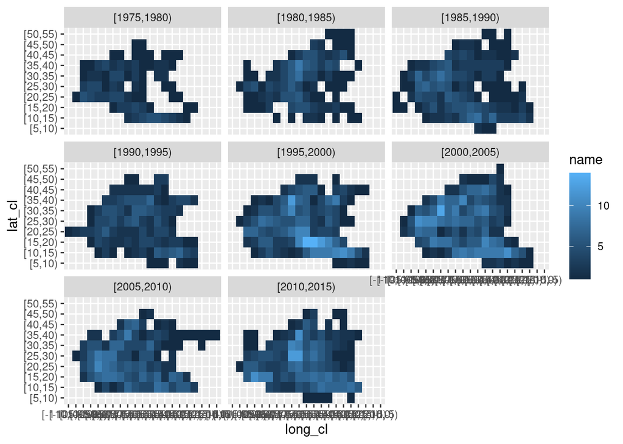

```r
storms$lat_cl = cut(storms$lat, seq(5, 55, 5), right = FALSE)
storms$long_cl = cut(storms$long, seq(-110, -5, 5), right = FALSE)
storms$yr_cl = cut(storms$year, seq(1975, 2015, 5), right = FALSE)
library(ggplot2)
fn = function(x) length(unique(x))
a = aggregate(storms["name"], storms[c("lat_cl", "long_cl", "yr_cl")], fn)
ggplot(a) + geom_raster(aes(x = long_cl, y = lat_cl, fill = name)) + facet_wrap(~yr_cl)
```

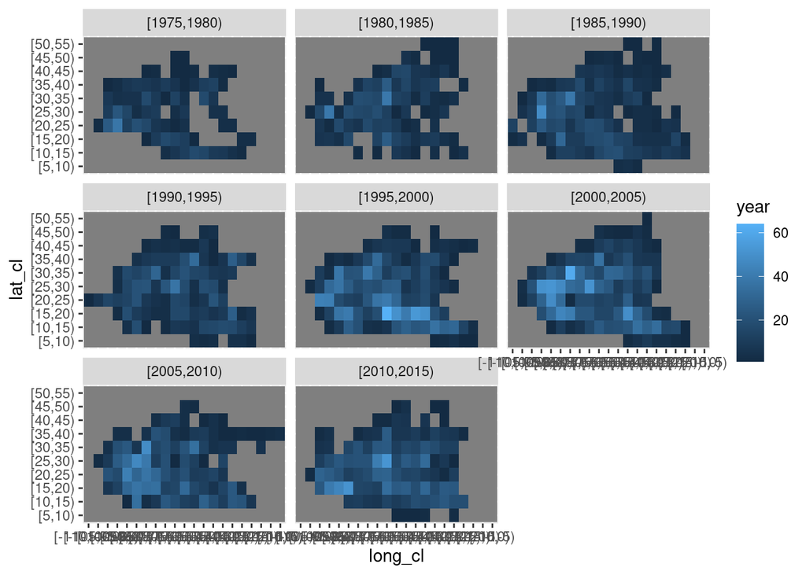

```r
a = aggregate(storms["year"], storms[c("lat_cl", "long_cl", "yr_cl")], length, drop = FALSE)
ggplot(a) + geom_raster(aes(x = long_cl, y = lat_cl, fill = year)) + facet_wrap(~yr_cl)
```

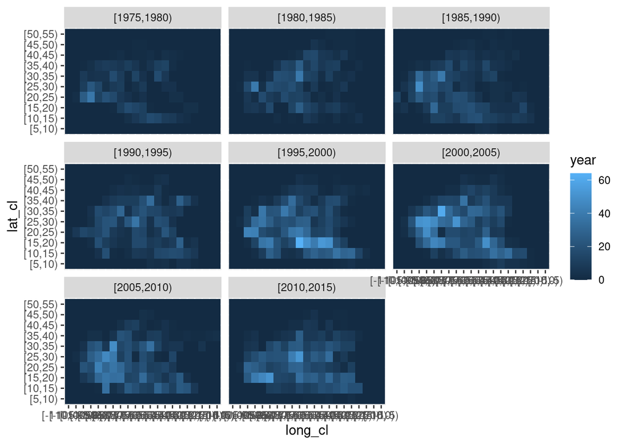

```r
a$year [ is.na(a$year) ] = 0
ggplot(a) + geom_raster(aes(x = long_cl, y = lat_cl, fill = year)) + facet_wrap(~yr_cl)
```

```r
# try this:
# a = aggregate(storms["year"], storms[c("lat_cl", "long_cl")], print, drop = FALSE)
s = sample(1985:2015, 50, replace = TRUE)
(ts = table(s))
```

```
## s
## 1986 1987 1988 1990 1991 1992 1993 1994 1995 1996 1997 1998 1999 2000 2001 2002
##    2    3    1    1    1    1    5    1    1    2    3    3    7    1    1    1
## 2003 2004 2005 2006 2007 2008 2009 2010 2012 2013 2014
##    1    2    1    2    2    1    2    1    1    1    2
```

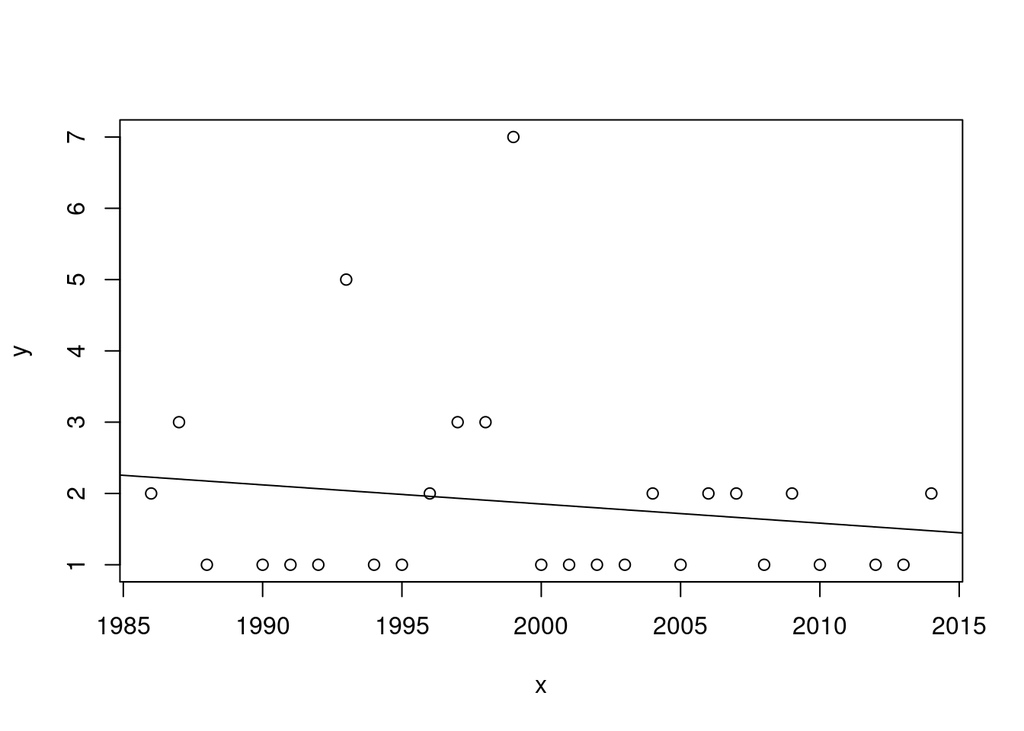

```r
x = as.numeric(names(ts))
y = as.numeric(ts)
plot(y~x)
abline(lm(y~x))
```

```r
coef(lm(y~x))
```

```
## (Intercept)           x
## 55.54312702 -0.02684564
```

```r
coef(lm(y~x))[["x"]]
```

```
## [1] -0.02684564
```

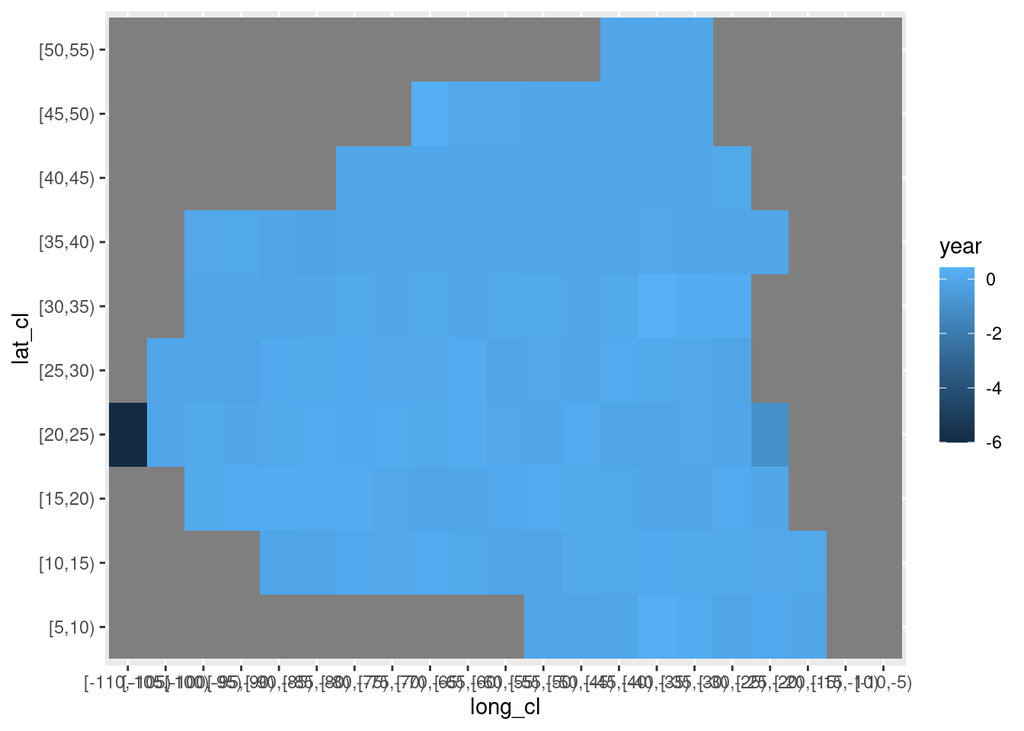

```r
get_slope = function(x) {
  ts = table(x)
  X = as.numeric(names(ts))
  y = as.numeric(ts)
  coef(lm(y~X))[["X"]]
}
a = aggregate(storms["year"], storms[c("lat_cl", "long_cl")], get_slope, drop = FALSE)
ggplot(a) + geom_raster(aes(x = long_cl, y = lat_cl, fill = year))
```

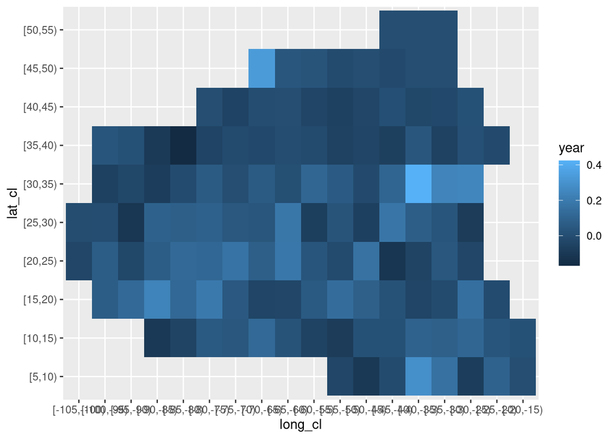

```r
ggplot(subset(a, year > -.7)) + geom_raster(aes(x = long_cl, y = lat_cl, fill = year))
```

Another solution is shown in these slides: https://edzer.github.io/rstudio_conf/2019/#1 with .Rmd found here: https://github.com/edzer/rstudio_conf/blob/master/2019/pres.Rmd